# Loan Eligibility's Effect on College Entrance

Author: Aileen Gui

Created: May 2020

```python
from IPython.display import display
from IPython.display import HTML
import IPython.core.display as di # Example: di.display_html('<h3>%s:</h3>' % str, raw=True)

# This line will hide code by default when the notebook is exported as HTML
di.display_html('<script>jQuery(function() {if (jQuery("body.notebook_app").length == 0) { jQuery(".input_area").toggle(); jQuery(".prompt").toggle();}});</script>', raw=True)

# This line will add a button to toggle visibility of code blocks, for use with the HTML export version
di.display_html('''<button onclick="jQuery('.input_area').toggle(); jQuery('.prompt').toggle();">Toggle code</button>''', raw=True)

#Source: https://stackoverflow.com/questions/27934885/how-to-hide-code-from-cells-in-ipython-notebook-visualized-with-nbviewer
```

```python
#Importing libraries. The same will be used throughout the article.
import numpy as np
import pandas as pd
import random
import matplotlib.pyplot as plt
%matplotlib inline
from matplotlib.pylab import rcParams
import matplotlib
#misc packages
import itertools
#plotting
import seaborn as sns
from mpl_toolkits import mplot3d
plt.rcParams['figure.figsize'] = (5,5)
#3d plotting at the end
import plotly.express as px
from IPython.display import Image
#stat analysis
from scipy import stats
from scipy import special
import statsmodels.api as sm
import statsmodels.formula.api as smf
import statsmodels
#Reminder on how to install packages
import sys
!{sys.executable} -m pip install Stargazer
from stargazer.stargazer import Stargazer
from IPython.core.display import HTML
from statsmodels.iolib.summary2 import summary_col
```

```
You are using pip version 9.0.3, however version 20.1.1 is available.
```

```python
#importing datasets
rd = pd.read_csv("project2020_rd.csv")
```

# Motivation

A policy question that floats around education reform literature is whether or not loan eligibility affects actual college entrance numbers. Put another way, does a student's access to loans affect whether or not they choose to enroll in college? We hypothesize that that if there is some jump around the cutoff threshold for loan eligibility in terms of how many students decide to enroll in college, and we can prove through regression-discontinuity methods that the jump is due to loan access, then we can conclude a causal link between loan accessibility and college enrollment.

# Data

"rd": This data set contains student level data for 112,008 students in Chile who finished high school and were eligible to enter college. In Chile students write a standardized test at the end of high school, called the "PSU" test. Students who score at least 475 points on the PSU test (with family incomes below the 80th percentile) are eligible for a loan from the government for college costs, while students who score less than 475 points cannot receive the loan. The variables on the dataset are:

- psu = The PSU test score (ranges from 300 to 700; the scores are numbers like 300.0, 301.0, 301.5...)
- over475 = 1 if PSU score is 475 or higher
- entercollege = 1 if student entered college
- gpa = high school GPA (scored from 0 to 70, 70 is "perfect")
- privatehs = 1 if student went to a private high school
- hidad = 1 if father has more than a high school education
- himom = 1 if mother has more than a high school education
- female = 1 if female student
- quintile = family income quintile (this has values 1,2,3,4 - families from the top quintile are not eligible for the loan program and are exluded from the data). Note that the shares of the student population in these quintiles is not equal, since the quintile cutoffs are based on all families including (richer) families with no kids.

# Estimating Characteristics of Compliers

Compliers are students who are eligibile for loan (PSU score >= 475) and enter college.

Goal: show the relationship between PSU and the probability of entering college

```python
#adding bins to dataset
binsarray = np.arange(min(rd['psu']), max(rd['psu']), 5)
rd['bins'] = pd.cut(x=rd['psu'], bins = binsarray)
```

First, we will plot how mean college entrance per 5-point PSU score bins changes with PSU score bins in order to see if there is some kind of discontinuity around the loan eligibility cutoff score of 475.

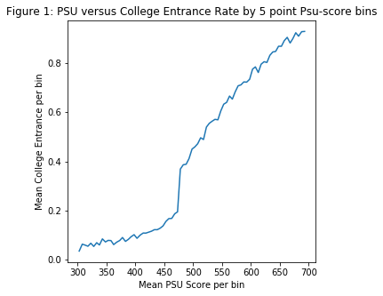

```python
psugraphdata = rd.groupby('bins').agg(np.mean)
psugraphdata
plt.plot(psugraphdata['psu'], psugraphdata['entercollege'])
plt.xlabel('Mean PSU Score per bin')
plt.ylabel('Mean College Entrance per bin')
plt.title('Figure 1: PSU versus College Entrance Rate by 5 point Psu-score bins')
```

Indeed, we see that there is essentially an almost straight vertical line around the PSU score 475, which indicates a "jump" around the cutoff threshold. This gives us motivation to continue assessing whether that jump exists because of access to loans.

We will set various bandwidths around 475 to see if there is a difference between students extremely close to the threshold, and students farther away in terms of college entrance.

```python
#creating new variables
table5data = rd
indicator475 = []
for value in table5data['psu']:
    if value >= 475:
        indicator475.append(0)
    else:
        indicator475.append(1)
table5data['psu>=475'] = indicator475
table5data['psu-475'] = table5data['psu']-475
table5data['interaction'] = table5data['psu>=475']*table5data['psu-475']

#selecting relevant columns
table5subsetdata = table5data[['psu>=475', 'psu-475', 'interaction']]
table5subsetdata = sm.add_constant(table5subsetdata)
dvar = rd[['entercollege']]

#fitting model
table5model = sm.OLS(dvar, table5subsetdata).fit()
```

```python
#results for bandwidth = 25
band25 = table5data[table5data['psu'] <= 500]
band25 = band25[band25['psu'] >= 450]
band25 = band25[['psu>=475', 'psu-475', 'interaction']]
band25 = sm.add_constant(band25)
dvar25 = rd[rd['psu'] <= 500]
dvar25 = dvar25[dvar25['psu'] >= 450][['entercollege']]


#fitting model
band25model = sm.OLS(dvar25, band25).fit()
```

```python
#results for bandwidth = 50
band50 = table5data[table5data['psu'] <= 525]
band50 = band50[band50['psu'] >= 425]
band50 = band50[['psu>=475', 'psu-475', 'interaction']]
band50 = sm.add_constant(band50)
dvar50 = rd[rd['psu'] <= 525]
dvar50 = dvar50[dvar50['psu'] >= 425][['entercollege']]


#fitting model
band50model = sm.OLS(dvar50, band50).fit()
```

```python
#results for bandwidth = 75
band75 = table5data[table5data['psu'] <= 550]
band75 = band75[band75['psu'] >= 400]
band75 = band75[['psu>=475', 'psu-475', 'interaction']]
band75 = sm.add_constant(band75)
dvar75 = rd[rd['psu'] <= 550]
dvar75 = dvar75[dvar75['psu'] >= 400][['entercollege']]


#fitting model
band75model = sm.OLS(dvar75, band75).fit()
```

```python
#results for bandwidth = 100
band100 = table5data[table5data['psu'] <= 575]
band100 = band100[band100['psu'] >= 375]
band100 = band100[['psu>=475', 'psu-475', 'interaction']]
band100 = sm.add_constant(band100)
dvar100 = rd[rd['psu'] <= 575]
dvar100 = dvar100[dvar100['psu'] >= 375][['entercollege']]


#fitting model
band100model = sm.OLS(dvar100, band100).fit()
```

```python
#Table representation of results
q5results = Stargazer([band25model, band50model, band75model, band100model])
q5results.custom_columns(["Bandwidth = 25", "Bandwidth = 50", "Bandwidth = 75", "Bandwidth = 100"], [1,1,1,1])
q5results.title("Table 1: Examining College Entrance Characteristics")
HTML(q5results.render_html())
```

Table 1: Examining College Entrance Characteristics

|  | *Dependent variable:* |  |  |  |
| --- | --- | --- | --- | --- |
|  | Bandwidth = 25 | Bandwidth = 50 | Bandwidth = 75 | Bandwidth = 100 |
|  | (1) | (2) | (3) | (4) |
| const | 0.351*** | 0.353*** | 0.358*** | 0.36*** |
|  | (0.008) | (0.006) | (0.005) | (0.004) |
| interaction | -0.003*** | -0.002*** | -0.002*** | -0.002*** |
|  | (0.001) | (0.0) | (0.0) | (0.0) |
| psu-475 | 0.004*** | 0.004*** | 0.003*** | 0.003*** |
|  | (0.001) | (0.0) | (0.0) | (0.0) |
| psu>=475 | -0.17*** | -0.165*** | -0.177*** | -0.184*** |
|  | (0.012) | (0.008) | (0.007) | (0.006) |
| Observations | 22846.0 | 43852.0 | 63070.0 | 79523.0 |
| R<sup>2</sup> | 0.066 | 0.11 | 0.152 | 0.194 |
| Adjusted R<sup>2</sup> | 0.066 | 0.11 | 0.152 | 0.194 |
| Residual Std. Error | 0.44(df = 22842.0) | 0.436(df = 43848.0) | 0.434(df = 63066.0) | 0.43(df = 79519.0) |
| F Statistic | 535.472***(df = 3.0; 22842.0) | 1814.93***(df = 3.0; 43848.0) | 3774.039***(df = 3.0; 63066.0) | 6371.063***(df = 3.0; 79519.0) |
| Note: | *p<0.1; **p<0.05; ***p<0.01 |  |  |  |

Next, we will plot the estimates of the average effect of PSU score on college entrance (we will refer to this as `pi_1` and the `+- 2` standard error confidence bands for each estimate against the bandwidth choice.

```python
x = np.arange(25, 225, 25)
y_vals = []
se_vals = []
for band in x:
    upper = 475 + band
    lower = 475 - band
    band = table5data[table5data['psu'] <= upper]
    band = band[band['psu'] >= lower]
    band = band[['psu>=475', 'psu-475', 'interaction']]
    band = sm.add_constant(band)
    dvar_gen = rd[rd['psu'] <= upper]
    dvar_gen = dvar_gen[dvar_gen['psu'] >= lower][['entercollege']]
    #fitting model

    bandmodel = sm.OLS(dvar_gen, band).fit()
    y_vals.append(bandmodel.params[1])
    se_vals.append(bandmodel.bse[1])

se_vals = [val*2 for val in se_vals]
```

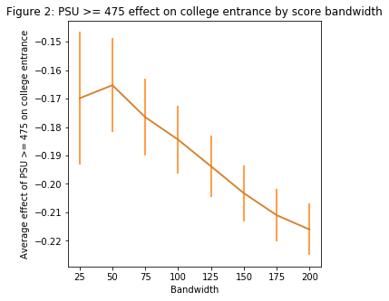

```python
plt.plot(x, y_vals)
plt.errorbar(
x = x,
y = y_vals,
yerr = se_vals)
plt.xlabel("Bandwidth")
plt.ylabel("Average effect of PSU >= 475 on college entrance")
plt.title("Figure 2: PSU >= 475 effect on college entrance by score bandwidth")
```

# Mean Characteristics of PSU Test Takers

Next, we will determine if there are any systematic differences between quintiles of PSU test takers. The rationale is that if we zoom in close to the cutoff threshold, and there are virtually no systematic differences between test takers, then the difference in college entrance can be attributed to loan eligibility.

```python
#initialize with dataset and empty dataframe
def choicedataframe(data, frame):
    quint1 = np.mean([data['quintile'] == 1])
    quint2 = np.mean([data['quintile'] == 2])
    quint3 = np.mean([data['quintile'] == 3])
    quint4 = np.mean([data['quintile'] == 4])
    sharefemale = np.mean([data['female'] == 1])
    sharegpa6070 = np.mean([(data['gpa'] >= 60) & (data['gpa'] <= 70)])
    sharegpa5060 = np.mean([(data['gpa'] >= 50) & (data['gpa'] <= 60)])
    sharegpa50less = np.mean([data['gpa'] <50])
    motheredhsabove = np.mean([data['himom'] == 1])
    fatheredhsabove = np.mean([data['hidad'] == 1])

    frame['quint1'] = [quint1]
    frame['quint2'] = quint2
    frame['quint3'] = quint3
    frame['quint4'] = quint4
    frame['sharefemale'] = sharefemale
    frame['gpa between 60 and 70'] = sharegpa6070
    frame['gpa between 50 and 60'] = sharegpa5060
    frame['gpa less than 50'] = sharegpa50less
    frame['mother with education >= HS'] = motheredhsabove
    frame['father with education >= HS'] = fatheredhsabove

    return frame
```

```python
#bandwidth choice = 50
bandwidthchoice = pd.DataFrame()

table6data = table5data[table5data['psu'] <= 525]
table6data = table6data[table6data['psu'] >= 425]

#run function to generate dataframe with mean values according to bandwidth = 50 restriction
choicedataframe(table6data, bandwidthchoice)
bandwidthchoice = bandwidthchoice.rename(index = {0: "bandwidth sample"})
```

```python
#entire dataset
entireset = pd.DataFrame()
choicedataframe(table5data, entireset)
entireset = entireset.rename(index = {0: "entire sample"})
```

```python
#complier dataset
complierdata = table5data
complierdata = complierdata[(complierdata['psu'] >= 475) & (complierdata['quintile'] != 4) & (complierdata['entercollege'] ==1)]
compliers = pd.DataFrame()
choicedataframe(complierdata, compliers)
compliers = compliers.rename(index = {0: 'compliers only'})
```

```python
#ratio of the mean of each characteristic for the compliers versus the entire sample
compliersvsentire = pd.DataFrame()
intermediate = []
for value in np.arange(10):
    intermediate.append(compliers.iloc[0][value]/entireset.iloc[0][value])
compliersvsentire['quint1'] = [intermediate[0]]
compliersvsentire['quint2'] = intermediate[1]
compliersvsentire['quint3'] = intermediate[2]
compliersvsentire['quint4'] = intermediate[3]
compliersvsentire['sharefemale'] = intermediate[4]
compliersvsentire['gpa between 60 and 70'] = intermediate[5]
compliersvsentire['gpa between 50 and 60'] = intermediate[6]
compliersvsentire['gpa less than 50'] = intermediate[7]
compliersvsentire['mother with education >= HS'] = intermediate[8]
compliersvsentire['father with education >= HS'] = intermediate[9]
compliersvsentire = compliersvsentire.rename(index = {0: "Ratio of mean of compliers vs entire sample"})
```

```python
table6 = pd.concat([bandwidthchoice, entireset, compliers, compliersvsentire])
table6.index = ["bandwidth choice", "entire sample", "compliers only", "ratio of compliers vs entire sample"]
table6.style.set_caption("Table 2: Mean Characteristics of PSU Test Takers ")
```

Table 2: Mean Characteristics of PSU Test Takers

|  | quint1 | quint2 | quint3 | quint4 | sharefemale | gpa between 60 and 70 | gpa between 50 and 60 | gpa less than 50 | mother with education >= HS | father with education >= HS |
| --- | --- | --- | --- | --- | --- | --- | --- | --- | --- | --- |
| bandwidth choice | 0.52155 | 0.215292 | 0.144532 | 0.118626 | 0.589711 | 0.224574 | 0.776635 | 0.0575116 | 0.113746 | 0.117988 |
| entire sample | 0.472564 | 0.216368 | 0.159123 | 0.151945 | 0.568504 | 0.318852 | 0.691424 | 0.0545318 | 0.148284 | 0.155587 |
| compliers only | 0.471688 | 0.286151 | 0.242162 | 0 | 0.538421 | 0.511299 | 0.554083 | 0.016338 | 0.164027 | 0.178719 |
| ratio of compliers vs entire sample | 0.998144 | 1.32252 | 1.52186 | 0 | 0.947084 | 1.60356 | 0.801365 | 0.299606 | 1.10617 | 1.14868 |

Compliers are also comprised primarily of high-gpa students. While the share of students in the unfiltered dataset who hold a gpa between 60 and 70 is 0.3189, the share of students in the complier group who fall in that same category is 0.5113. These are extremely high performing students.

Compared to the unfiltered dataset, mothers and fathers of the compliers have higher rates of high school graduation and higher education.